# 目 录

### 5.3.2 不调用Function，直接运行助手

此时，如果不调用Function，直接运行助手，我们看看会发生什么。

```
# 创建一个新的Thread
thread = client.beta.threads.create()
print(f"Thread的信息:\n{thread}\n")

# 在Thread中添加用户的消息
message = client.beta.threads.messages.create(
    thread_id=thread.id,
    role="user",
    content="你好，请和我随便说句话吧！"
)
print(f"Message的信息:\n{message}\n")

# 运行助手来处理Thread
run = client.beta.threads.runs.create(
  thread_id=thread.id,
  assistant_id=assistant_id
)
print(f"Run的初始信息:\n{message}\n")

# 轮询以检查Run的状态
import time
n = 0
while True:
    n += 1
    run = client.beta.threads.runs.retrieve(
        thread_id=thread.id,
        run_id=run.id
    )
    print(f"Run的第{n}次轮询信息:\n{run}\n")
    if run.status == 'completed':
        break
    time.sleep(5)  # 等待5s后再次检查

# 获取助手在Thread中的回应
messages = client.beta.threads.messages.list(
  thread_id=thread.id
)

# 输出助手的回应
for message in messages.data:
    if message.role == "assistant":
        print(f"助手的回应:\n{ message.content }\n")
```

[output not shown]

前面的输出冗长难读 ，这里只列出重要的信息，如表5.3所示。

表5.3 助手、Thread、Messages以及Run的状态信息（1）

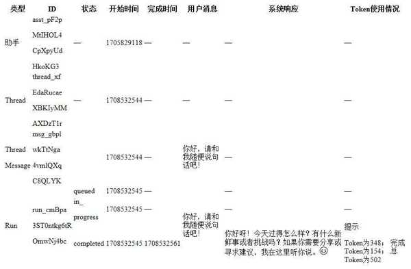

此时，Run的状态经历从queued、in_progress到completed，最后完成对话（见图5.11）。助手给出了一个看起来还不错的回答。

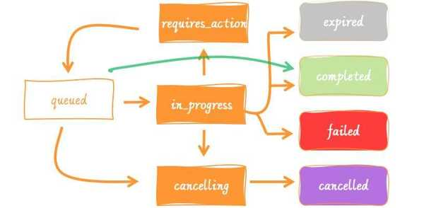

图5.11 Run在这个示例中的流程

然而，如果想通过直接执行上面的代码来抚慰小雪的心情的话，结果是十分“危险”的。

小雪：为什么？

咖哥：我们试试看。下面就来谈谈你的情绪。代码的逻辑不变，只需要调整对话内容。（此时我们重新运行程序，在后面的输出中，Thread和Run的ID会发生改变，不过由于使用同样的助手，因此助手的ID不变。）

```
# 导入OpenAI库，并创建client
from dotenv import load_dotenv
load_dotenv()
from openai import OpenAI
client = OpenAI()

# 检索你之前创建的助手
assistant_id = "asst_pF2pMtIHOL4CpXpyUdHkoKG3" # 你自己的助手的ID
assistant = client.beta.assistants.retrieve(assistant_id)
print(f"助手的信息:\n{assistant}\n")

# 创建一个新的Thread
thread = client.beta.threads.create()
print(f"Thread的信息:\n{thread}\n")

# 在Thread中添加用户的消息
message = client.beta.threads.messages.create(
    thread_id=thread.id,
    role="user",
    content="你好，请你安慰一下伤心的小雪吧！"  # 只有这一句发生变化
)
print(f"Message的信息:\n{message}\n")

# 运行助手来处理Thread
run = client.beta.threads.runs.create(
  thread_id=thread.id,
  assistant_id=assistant_id
)
print(f"Run的初始信息:\n{run}\n")

# 轮询以检查Run的状态
import time
n = 0
while True:
    n += 1
    run = client.beta.threads.runs.retrieve(
        thread_id=thread.id,
        run_id=run.id
    )
    print(f"Run的第{n}次轮询信息:\n{run}\n")
    if run.status == 'completed':
        break
    time.sleep(5)  # 等待5s后再次检查

# 获取助手在Thread中的回应
messages = client.beta.threads.messages.list(
  thread_id=thread.id
)

# 输出助手的回应
for message in messages.data:
    if message.role == "assistant":
        print(f"Message返回的信息:\n{message.content}\n")
```

[output not shown]

小雪：咦，咖哥，怎么回事？怎么轮询100多次？

咖哥：是啊。此时，程序进入无限循环，一直卡在requires_action（等待函数调用）状态，我只好按Ctrl+C快捷键强行退出。

输出结果中的重要信息如表5.4所示。

表5.4 助手、Thread、Messages以及Run的状态信息（2）

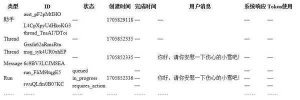

咖哥：小雪，此时产生的现象为什么和刚才不同？助手不但没有很快给出结果并将Run的状态转变为进入completed，而是似乎进入了一个无休止的“轮回”。

小雪：我也发现Run的状态持续在requires_action中循环。不必卖关子，你说一下。

咖哥：因为此时助手已经知道这不是一次普通的聊天，而是一个与情感相关的问题。作为一个情感助手，而且武装了相关工具，它知道自己应该调用get_encouragement函数来完成这次对话，而不是随意回答。

小雪突然跳了起来：啊！我明白了，但是由于在程序中又没有通过调用get_encouragement函数来提交返回结果的逻辑，因此Run就一直处在requires_action状态，无法给出情感支持的对话内容（见图5.12）。

所以，我们务必要改变轮询的循环逻辑，不能只在Run的状态为completed时才结束循环，而是要在Run的状态为requires_action时也跳出循环。

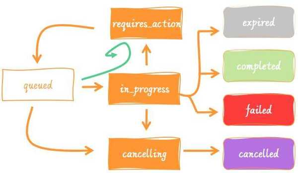

图5.12 Run在这个示例中的流程：无休止等待

### 5.3.3 在Run进入requires_action状态之后跳出循环

接下来我们重构轮询逻辑，在Run进入requires_action状态之后跳出循环。（由于重构代码后，我们重新运行程序，因此，在后面的输出中Thread和Run的ID又会发生变化。）

```
# 轮询Run，等待Run的状态从queue转变为completed或者requires_action
import time
# 定义轮询函数
def poll_run_status(client, thread_id, run_id, interval=5):
    n = 0
    while True:
        n += 1
        run = client.beta.threads.runs.retrieve(thread_id=thread_id,
                                 run_id=run_id)
        print(f"Run的第{n}次轮询信息:\n{run}\n")
        if run.status in ['requires_action', 'completed']:
            return run
        time.sleep(interval)  # 等待后再次检查
# 轮询以检查Run的状态
run = poll_run_status(client, thread.id, run.id)
```

运行上述代码，Run的状态从queue转变为in_progress，然后转变为requires_action，最后Run跳出循环。如果你再次查询Run的状态，可以发现Run的状态仍然是requires_action。（这里不再重复展示和表5.4类似的输出内容。）

小雪：知道了，知道了，咖哥。这时助手在等待Function Calling的结果，由于我们只是修改了轮询时的退出逻辑，因此，虽然创建了新的Thread和Run，但是Run的状态变化流程与刚才一样。

### 5.3.4 拿到助手返回的元数据信息

接下来我们马上进入关键步骤。此时，我们需要读取function_name、arguments、function_id等重要的信息。代码如下。

```
# 定义一个从Run中读取Function的元数据的函数
def get_function_details(run):
  function_name = run.required_action.submit_tool_outputs.tool_calls[0].function.name
  arguments = run.required_action.submit_tool_outputs.tool_calls[0].function.arguments
  function_id = run.required_action.submit_tool_outputs.tool_calls[0].id
  return function_name, arguments, function_id
# 拿到Function的元数据
function_name, arguments, function_id = get_function_details(run)
print("function_name:", function_name)
print("arguments:", arguments)
print("function_id:", function_id)
```

```
function_name: get_encouragement
arguments: {"mood":"难过","name":"小雪"}
function_id: call_s6vSerztJc09mmKDQyfkjmrJ
```

小雪：function_name、arguments、function_id等信息一定是本地函数调用时所需要的。

咖哥：对。下一步当然是用Run给出的函数的这些参数信息来执行后续的代码，以便调用函数。助手所做的就是把人类的对话转换成函数能够读取的input参数。

现在你可以理解图5.9中的信息了吧？我们的对话被助手转换成函数可以访问的元数据，如表5.5所示。

表5.5 人类语言、函数语言与助手的标记的对比

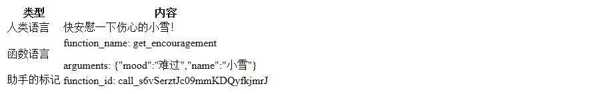

### 5.3.5 通过助手的返回信息调用函数

因此，我们需要定义一个鼓励函数。这个函数可以首先将收到的用户当前的情绪信息作为输入，然后返回一个带有鼓励信息的文本。

```
# 定义一个鼓励函数
def get_encouragement(mood, name=None):
    encouragement_messages = {
        "开心": "看到你这么阳光真好！保持这份积极！",
        "难过": "记得，每片乌云背后都有阳光。",
        "压力大": "深呼吸，慢慢呼出，一切都会好起来。",
        "疲倦": "你已经很努力，现在是时候休息一下了。"
    }
    # 如果提供了名字，则输出个性化消息
    if name:
        message = f"{name}，{encouragement_messages.get(mood, '抬头挺胸，一切都会变好。')}"
    else:
        message = encouragement_messages.get(mood, '抬头挺胸，一切都会变好。')
    return message
```

我们在前面内容中已经见过这个函数。

那么，如何通过function_name、arguments动态判断调用的函数，以及为什么要调用这个函数？

小雪：这个问题难不倒我，请看下面的代码。

```
# 将 JSON 字符串转换为字典
import json
arguments_dict = json.loads(arguments)
# 从字典中提取 'name' 和 'mood'
name = arguments_dict['name']
mood = arguments_dict['mood']
# 调用函数
encouragement_message = get_encouragement(name, mood)
# 打印结果以便验证
print(encouragement_message)
```

[output not shown]

小雪：嗯。我再改改。

```
# 在这里，我可要动态调用程序了
# 定义可用的函数字典
available_functions = {
    "get_encouragement": get_encouragement
}
# 解析参数
import json
function_args = json.loads(arguments)
# 动态调用函数
function_to_call = available_functions[function_name]
encouragement_message = function_to_call(
    name=function_args.get("name"),
    mood=function_args.get("mood")
)
# 打印结果以便验证
print(encouragement_message)
```

[output not shown]

咖哥：这就对了。用字典将函数名映射到函数对象，从而实现动态调用函数，也就是根据Function Calling的返回值function_name调用不同的函数。

### 5.3.6 通过submit_tool_outputs提交结果以完成任务

看上去，我们在助手的辅助下完成任务。本地函数get_encouragement也返回了一个结果。

在这里助手所做的只是把自然语言转换成函数的名称和调用格式。

不过，我们还需要完成最后一步——通知Run任务已经完成。最后要有一个交代，否则这个Run大约10min之后会过期（Run的状态转变为expired，见图5.13）。

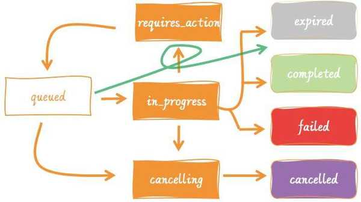

图5.13 没有人理会的Run在生存期结束后就会过期，将无法继续对话

小雪：对啊，对啊。虽然我们跳出循环，也调用了函数，但是Run还是一直挂在那里等待一个说法（函数调用的结果）。对话不会自动进入completed状态，也不会重新回到queued状态。

接下来介绍最后一个步骤。通过submit_tool_outputs API完成Run。

###### 咖哥发言

因为Run有时效性，生存周期大约10min，所以不要让Run等待太久，应及时提交调用结果，否则Run就会进入expired状态，这样的话它将接收不到submit_tool_outputs的结果。

调用submit_tool_outputs API提交结果的代码如下。这里要确保tool_call_id准确引用每个function_id，以便将响应结果与Function Calling相匹配。

```
# 定义提交结果的函数
def submit_tool_outputs(run,thread,function_id,function_response):
    run = client.beta.threads.runs.submit_tool_outputs(
    thread_id=thread.id,
    run_id=run.id,
    tool_outputs=[
      {
        "tool_call_id": function_id,
        "output": str(function_response),
      }
    ]
    )
return run
# 向Run提交结果
run = submit_tool_outputs(run,thread,function_id,encouragement_message)
print('这时，Run收到结果')
print(run)
```

```
Run(id='run_5r5k1C8u9Bh8aVYtBw0LOZzO', assistant_id='asst_pF2pMtIHOL4CpXpyUdHkoKG3', cancelled_at=None, completed_at=None, created_at=1708534757, expires_at=1708535357, failed_at=None, file_ids=[], instructions='你是一个很会鼓励人的助手！', last_error=None, metadata={}, model='gpt-4-turbo-preview', object='thread.run', required_action=None, started_at=1708534757, status='queued', thread_id='thread_Ko2xY4FmKV5ZEU2rpXncHuCk', tools=[ToolAssistantToolsFunction(function=FunctionDefinition(name='get_encouragement', description='根据用户的心情提供鼓励信息', parameters={'type': 'object', 'properties': {'mood': {'type': 'string', 'description': '用户当前的心情，例如：开心，难过，压力大，疲倦'}, 'name': {'type': 'string', 'description': '用户的名字，用来个性化鼓励信息'}}, 'required': ['mood']}), type='function')], usage=None)
```

提交输出后，可以发现，此时Run回到queued状态，等待系统资源以便继续运行（见图5.14）。

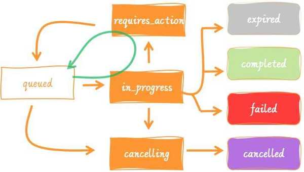

图5.14 Run回到queued状态

我们继续轮询Run的状态。可以发现，助手会利用鼓励函数的输出结果来继续这一轮Run对话，之后生成总结陈词式的回答。

```
# 再次轮询Run直至完成
run = poll_run_status(client, thread.id, run.id)
print('这时，Run继续执行直至完成')
print(run)
```

```
Run的第1次轮询信息:
Run(id='run_5r5k1C8u9Bh8aVYtBw0LOZzO', assistant_id='asst_pF2pMtIHOL4CpXpyUdHkoKG3', cancelled_at=None, completed_at=None, created_at=1708534757, expires_at=1708535357, failed_at=None, file_ids=[], instructions='你是一个很会鼓励人的助手！', last_error=None, metadata={}, model='gpt-4-turbo-preview', object='thread.run', required_action=None, started_at=1708534763, status='in_progress', thread_id='thread_Ko2xY4FmKV5ZEU2rpXncHuCk', tools=[ToolAssistantToolsFunction(function=FunctionDefinition(name='get_encouragement', description='根据用户的心情提供鼓励信息', parameters={'type': 'object', 'properties': {'mood': {'type': 'string', 'description': '用户当前的心情，例如：开心，难过，压力大，疲倦'}, 'name': {'type': 'string', 'description': '用户的名字，用来个性化鼓励信息'}}, 'required': ['mood']}), type='function')], usage=None)

Run的第2次轮询信息:
Run(id='run_5r5k1C8u9Bh8aVYtBw0LOZzO', assistant_id='asst_pF2pMtIHOL4CpXpyUdHkoKG3', cancelled_at=None, completed_at=None, created_at=1708534757, expires_at=1708535357, failed_at=None, file_ids=[], instructions='你是一个很会鼓励人的助手！', last_error=None, metadata={}, model='gpt-4-turbo-preview', object='thread.run', required_action=None, started_at=1708534763, status='in_progress', thread_id='thread_Ko2xY4FmKV5ZEU2rpXncHuCk', tools=[ToolAssistantToolsFunction(function=FunctionDefinition(name='get_encouragement', description='根据用户的心情提供鼓励信息', parameters={'type': 'object', 'properties': {'mood': {'type': 'string', 'description': '用户当前的心情，例如：开心，难过，压力大，疲倦'}, 'name': {'type': 'string', 'description': '用户的名字，用来个性化鼓励信息'}}, 'required': ['mood']}), type='function')], usage=None)

Run的第3次轮询信息:
Run(id='run_5r5k1C8u9Bh8aVYtBw0LOZzO', assistant_id='asst_pF2pMtIHOL4CpXpyUdHkoKG3', cancelled_
at=None, completed_at=1708534777, created_at=1708534757, expires_at=None, failed_at=None, file_ids=[], instructions='你是一个很会鼓励人的助手！', last_error=None, metadata={}, model='gpt-4-turbo-preview', object='thread.run', required_action=None, started_at=1708534763, status='completed', thread_id='thread_Ko2xY4FmKV5ZEU2rpXncHuCk', tools=[ToolAssistantToolsFunction(function=FunctionDefinition(name='get_encouragement', description='根据用户的心情提供鼓励信息', parameters={'type': 'object', 'properties': {'mood': {'type': 'string', 'description': '用户当前的心情，例如：开心，难过，压力大，疲倦'}, 'name': {'type': 'string', 'description': '用户的名字，用来个性化鼓励信息'}}, 'required': ['mood']}), type='function')], usage=Usage(completion_tokens=214, prompt_tokens=760, total_tokens=974))
```

这时，Run继续执行，几秒之后，从queued状态转变为in_progress状态，继续轮询，直至完成。Run最终转变为completed状态。助手的任务结束，并给出最终的对话文本。

从开始到最后，包含Function Calling的Run的状态流转过程如图5.15所示。

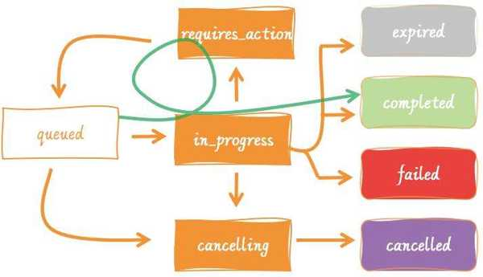

图5.15 包含Function Calling 的Run的状态流转过程

下面打印最终的Message。

```
# 获取助手在Thread中的回应
messages = client.beta.threads.messages.list(
  thread_id=thread.id
)
# 输出助手的回应
print('打印最终的Message')
for message in messages.data:
    if message.role == "assistant":
        print(f"最终返回的信息:\n{message.content}\n")
```

```
最终返回的信息:
[MessageContentText(text=Text(annotations=[], value=’亲爱的小雪，请记住，无论今天发生了什么，你都不是孤独一人。我会守候在这里，给你最大的支持和安慰。每一次挑战，都是成长的机会，信任你自己的力量，你会发现那些使你难过的事情最终会变成你的宝贵经历。让自己伤心是没问题的，允许自己感受那些情绪，但同时也要相信，事情总会变得更好。加油，小雪！我相信你能度过这一切。 ’), type=’text’)]
```

小雪：鼓励收到，心情不错！不过，整个流程的确有点绕。

咖哥：是的。包含Function Calling 的Run的完整状态如表5.6所示。

表5.6 包含Function Calling 的Run的完整状态

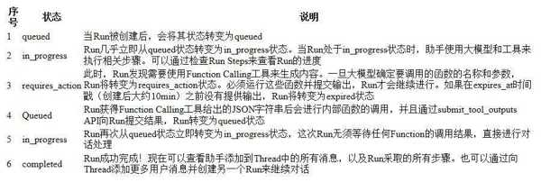

咖哥：那么前面的这个Run状态流转的过程与第一次直接和ChatGPT进行普通的聊天相比，发生了什么？有什么不同？

## 5.4 通过ChatCompletion API来实现Tool Calls

前面，我们对助手的Function Calling进行了详细说明。接下来，趁热打铁，再给出一个类似的示例。不过，这次我们重点介绍ChatCompletion（聊天完成） API 的Tool Calls。具体流程和上个示例的几乎完全一致。

和助手一样，在 ChatCompletion API 中，我们可以描述函数，并让大模型智能地输出一个包含用于调用一个或多个函数的参数的 JSON 对象。ChatCompletion API 不会调用该函数，只会生成函数调用所需的JSON结构。之后我们可以使用JSON结构来调用代码中的函数，从而得到想要的结果。

小雪：这次给花语秘境开发一个自动查库存的Agent吧！

咖哥：好，我们开发一个在一次响应中多次调用函数的示例。和5.3节的流程完全相同，首先定义一个用于获取鲜花库存的函数，并在与大模型的对话中引用这个函数。程序发送用户的问题到大模型，并指定可用的函数。如果大模型确定需要调用函数，程序会运行相应的函数，并将结果返回给大模型以继续对话。

### 5.4.1 初始化对话和定义可用函数

首先，我们定义一个可以获取鲜花库存的函数和一个对函数参数进行说明的tools（工具）列表。这个工具列表就是我们多次提到的JSON说明文字。这里只有一个函数，如果有多个函数，可以把这些函数附加到（append）这个列表中。

```
# 创建client
from openai import OpenAI
client = OpenAI()
# 定义查询鲜花库存的函数
def get_flower_inventory(city):
    """获取指定城市的鲜花库存"""
    if "北京" in city:
        return json.dumps({"city": "北京", "inventory": "玫瑰: 100, 郁金香: 150"})
    elif "上海" in city:
        return json.dumps({"city": "上海", "inventory": "百合: 80, 康乃馨: 120"})
    elif "深圳" in city:
        return json.dumps({"city": "深圳", "inventory": "向日葵: 200, 玉兰: 90"})
    else:
        return json.dumps({"city": city, "inventory": "未知"})

# 定义工具列表（函数元数据）
tools = [
    {
        "type": "function",
        "function": {
            "name": "get_flower_inventory",
            "description": "获取指定城市的鲜花库存",
            "parameters": {
                "type": "object",
                "properties": {
                    "city": {
                        "type": "string",
                        "description": "城市名称，如北京、上海或深圳"
                    }
                },
                "required": ["city"]
            }
        }
    }
]
```

上述代码定义了一个简单的函数 get_flower_inventory，旨在根据不同城市名称返回相应鲜花库存的查询功能。此外，上述代码还定义了一个工具列表，用于通过元数据描述该函数，使其能够作为一个工具在某些上下文中被调用。

当然，这个函数的内部逻辑较为粗糙，在实际应用中，可以强化代码实现部分，并链接数据库以实现真实的库存查询。

小雪：明白。

### 5.4.2 第一次调用大模型，向模型发送对话及工具定义，并获取响应

接下来，首先在messages中初始化对话内容，然后将对话内容和工具定义发送给大模型，并获取大模型的初步响应。

在这里，因为我们没有使用Assistants，而是直接调用大模型，所以我们不必创建助手和线程这些组件。

```
# 初始化对话内容
messages = [{"role": "user", "content": "北京、上海和深圳的鲜花库存是多少？"}]
print("message:", messages)

# 第一次对话响应
first_response = client.chat.completions.create(
    model="gpt-3.5-turbo",
    messages=messages,
    tools=tools,
    tool_choice="auto"
)

# 打印响应的内容
print(first_response)
response_message = first_response.choices[0].message
```

```
message: [{'role': 'user', 'content': '北京、上海和深圳的鲜花库存是多少？'}]
first_response:
ChatCompletion(
  id='chatcmpl-8pp0atDsIXTE0NesPItrFDNZ5Kszj',
  choices=[Choice(finish_reason='tool_calls', index=0, logprobs=None,
  message=ChatCompletionMessage(content=None, role='assistant', function_call=None,
  tool_calls=[ChatCompletionMessageToolCall(id='call_DhKVYSzAsqJ2DKkYLhmlhNYH',
  function=Function(arguments='{"city": "北京"}', name='get_flower_inventory'), type='function'),
  ChatCompletionMessageToolCall(id='call_EW6HrY9A0WUV40KsOifY7cfY',
  function=Function(arguments='{"city": "上海"}', name='get_flower_inventory'), type='function'),
  ChatCompletionMessageToolCall(id='call_g9yh7ebEzIU8vc1Cx0OkGYK8',
  function=Function(arguments='{"city": "深圳"}', name='get_flower_inventory'), type='function')]))],
  created=1707361496, model='gpt-3.5-turbo', object='chat.completion',
  system_fingerprint='fp_69829325d0', usage=CompletionUsage(completion_tokens=67, prompt_tokens=95, total_tokens=162))
```

ChatCompletion结构的参数说明如下。

id='chatcmpl-8pp0atDsIXTE0NesPItrFDNZ5Kszj'，表示本次对话完成的ID。

choices表示包含大模型生成的所有回答的数组。在本示例中，由于请求的是工具调用，因此大模型生成的所有回答中的主要内容是工具调用的请求而非文本回答。相关参数说明如下。

■ finish_reason='tool_calls'，表示对话结束的原因是需要执行工具调用。

■ index=0，表示这是第一个（也是唯一一个）生成的回答的索引。

■ logprobs=None，表示没有返回回答的对数概率，因为调用时没有请求它。

message包含的参数说明如下。

■ content=None，表示这个阶段的输出是工具调用请求，而不是具体的回答内容。

■ role='assistant'，表示这是助手的行为，即请求工具调用。

tool_calls列出了如下所有请求的工具调用。

■ 包含3个工具调用请求，分别针对“北京”“上海”和“深圳”3座城市的get_flower_inventory函数。

■ 每个工具调用都只有一个ID（如call_DhKVYSzAsqJ2DKkYLhmlhNYH）和指定的函数名称（如get_flower_inventory）以及函数参数（如{"city":"北京"}）。

created=1707361496，表示回答创建的时间戳。

model='gpt-3.5-turbo'，表示生成回答的大模型。

object='chat.completion'，表示这是一个聊天完成对象。

system_fingerprint='fp_69829325d0'，表示系统用于跟踪和优化性能的内部标记。

usage提供了关于此次调用的详细使用信息。参数说明如下。

■ completion_tokens=67，表示生成请求工具调用的过程中使用了67个Token。

■ prompt_tokens=95，表示输入提示文本使用了95个Token。

■ total_tokens=162，表示总共使用了162个Token。

上述输出展示了大模型在处理用户请求时，识别出需要进行3次工具调用，以便分别获取北京、上海和深圳的鲜花库存信息。这3次工具调用也可以分别指向不同的函数（工具）。

在前面的内容中，我们反复强调，这个输出只是利用大模型返回工具调用的参数，还不是最终的结果。此时，大模型并没有提供具体的回答内容，而是生成了对应的工具调用请求，等待这些工具调用被执行并返回结果。

'{"city": "北京"}'作为一个JSON对象与我们在Assistants API实现Function Calling中看到的相同。无论是Assistants API，还是ChatCompletion API，只要用到Function Calling或者Tool Calls，就会默认启用之前提到的“JSON模式”，以确保大模型输出的参数和返回值是结构化的，是可以被正确解析的有效的JSON对象。

###### 咖哥发言

JSON模式的特点和注意事项如下。

■ 当启用JSON模式时，大模型被限制只生成能解析为有效JSON对象的字符串。

■ 为了确保大模型按照预期生成JSON格式的数据，可以在对话中的某处，通常是在系统消息中，明确指示大模型生成JSON格式的数据。例如，通过下面的系统消息来引导大模型生成JSON格式的数据。

```
{
"role": "system",
"content": "You are a helpful assistant designed to output JSON."
}
```

■ 如果没有在上下文中明确指示大模型生成JSON格式的数据，大模型可能会生成无限多的空白字符，并且请求可能会持续运行直至达到Token的上限。为了防止这种情况出现，如果在上下文中没有出现“JSON”这个字符串，API将反馈出错信息。

■ 如果生成内容达到Token的最大量（max_tokens）或者对话超过Token的数量限制，返回的JSON对象可能是不完整的。在解析响应结果之前，需要检查返回的 finish_reason 以确保JSON对象是完整的。

■ 虽然JSON模式保证输出是有效且无错误的JSON对象，但是它并不保证输出结果能匹配任何特定的架构或格式。

■ 当大模型在进行Function Calling时，JSON模式通过强制大模型输出符合JSON格式的数据，可以确保函数调用的参数和结果都是有效且易于处理的。这对于自动化处理和集成大模型输出到其他系统中非常重要。

### 5.4.3 调用模型选择的工具并构建新消息

接下来要检查大模型的响应结果中是否包含对工具的调用请求，也就是看看是否需要调用查询库存的函数并进行查询。

为实现函数调用，我们需要循环执行tool_calls，并为其中的每个条目调用get_flower_inventory函数，以得到库存信息。

要响应这些函数调用请求，需要向对话中添加3条新消息。其中，每条消息包含一个函数调用的结果，并通过tool_call_id引用tool_calls中的ID。

```
# 检查是否需要调用工具
tool_calls = response_message.tool_calls
if tool_calls:
messages.append(response_message)
# 如果需要调用工具，调用工具并添加库存查询结果
    for tool_call in tool_calls:
        function_name = tool_call.function.name
        function_args = json.loads(tool_call.function.arguments)
        function_response = get_flower_inventory(
            city=function_args.get("city")
        )
        messages.append(
            {
                "tool_call_id": tool_call.id,
                "role": "tool",
                "name": function_name,
                "content": function_response,
            }
        )
# 打印当前消息列表
print("message:", messages)
```

```
message: [{'role': 'user', 'content': '北京、上海和深圳的鲜花库存是多少？'},
ChatCompletionMessage(content=None, role='assistant', function_call=None,
tool_calls=[
ChatCompletionMessageToolCall(id='call_HgwcAAlWCyRwPFDib9dYxkUq', function=Function(arguments='{"city": "北京"}', name='get_flower_inventory'), type='function'), ChatCompletionMessageToolCall(id='call_2qEge0rKcpS4ZkY5QdY0pYdr', function=Function(arguments='{"city": "上海"}', name='get_flower_inventory'), type='function'), ChatCompletionMessageToolCall(id='call_nZlxb3ITZzi9eE5YFdHCzBBF', function=Function(arguments='{"city": "深圳"}', name='get_flower_inventory'), type='function')]),
{'tool_call_id': 'call_HgwcAAlWCyRwPFDib9dYxkUq', 'role': 'tool', 'name': 'get_flower_inventory', 'content': '{"city": "\\u5317\\u4eac", "inventory": "\\u73ab\\u7470: 100, \\u90c1\\u91d1\\u9999: 150"}'},
{'tool_call_id': 'call_2qEge0rKcpS4ZkY5QdY0pYdr', 'role': 'tool', 'name': 'get_flower_inventory', 'content': '{"city": "\\u4e0a\\u6d77", "inventory": "\\u767e\\u5408: 80, \\u5eb7\\u4e43\\u99a8: 120"}'},
{'tool_call_id': 'call_nZlxb3ITZzi9eE5YFdHCzBBF', 'role': 'tool', 'name': 'get_flower_inventory', 'content': '{"city": "\\u6df1\\u5733", "inventory": "\\u5411\\u65e5\\u8475: 200, \\u7389\\u5170: 90"}'}]
```

上述代码的执行流程如下。

1.检查是否有工具调用的需求（即tool_calls列表是否有元素）。

2.如果有工具调用的需求，将迭代执行工具调用，进而得到北京、上海和深圳3座城市的鲜花库存信息。

■ 提取工具调用的函数名称（function_name）和参数（function_args），这里的函数是get_flower_inventory。

■ 使用提取的参数（城市名）调用get_flower_inventory函数来获取对应城市的鲜花库存信息。

3.每次调用get_flower_inventory函数后，将创建一个包含工具调用ID、角色、函数名称和内容（库存信息）的消息，并将其添加到消息列表（messages）中。

4.打印出更新后的消息列表。该列表包含用户的原始查询信息和每座城市的鲜花库存信息。

更新后的消息列表包含的信息如表5.7所示。

表5.7 更新后的消息列表包含的信息

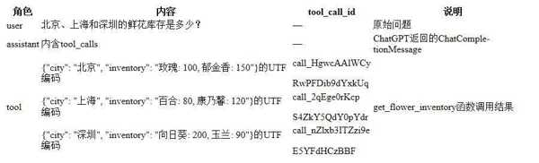

小雪：不过，咖哥，这里我有些疑惑：一是，你为什么要把函数的返回值附加到消息列表中；二是，为什么消息列表中显示的是UTF编码？

咖哥：这里显示的UTF编码应该是GPT模型内部进行编码转换后的结果。我们在阅读这个返回值时的确感觉不舒服。但是，应该有办法可以解决。你想一下，在通过Assistants API 实现Function Calling的示例中，我们最后一步要做什么？

小雪（想了一会儿）：我明白了。我们把这个包含库存工具查询结果的消息列表再次“丢给”大模型，让它先整合库存查询结果，然后生成人人都可以读懂的最终答案。

咖哥：聪明，不愧是小雪。

### 5.4.4 第二次向大模型发送对话以获取最终响应

最后，将更新后的消息列表第二次发送给大模型以获取最终响应。

```
# 第二次向大模型发送对话以获取最终响应
second_response = client.chat.completions.create(
    model="gpt-3.5-turbo",
    messages=new_messages
)
# 打印最终响应
final_response = second_response.choices[0].message
print(final_response)
```

[output not shown]

ChatCompletion结构的参数说明如下。

id='chatcmpl-8pp0cTdOj5aLn1Ny3t1ldRyXyoE9w'，表示本次对话完成的ID。

choices表示包含大模型生成的所有回答的数组。在本示例中，只有一个回答（因为大多数情况下，我们只请求一个回答）。相关参数说明如下。

■ finish_reason='stop'，表示大模型停止生成回答的原因。在本示例下，它自然地完成回答。

■ index=0，表示这是第一个（也是唯一一个）生成的回答的索引。

■ logprobs=None，表示没有返回回答的对数概率，因为调用时没有请求它。

message包含的参数说明如下。

■ content包含大模型生成的实际文本回答：对于北京，鲜花库存是“玫瑰：100，郁金香：150”；对于上海，鲜花库存是“百合：80，康乃馨：120”；对于深圳，鲜花库存是“向日葵：200，玉兰：90”。

■ role='assistant'，表示生成这段文本的角色，此处表明这是助手的回答。

created=1707361498，表示回答创建的时间戳。

model='gpt-3.5-turbo'，表示生成回答的大模型。

object='chat.completion'，表示这是一个聊天完成对象。

system_fingerprint='fp_69829325d0'，表示系统用于跟踪和优化性能的内部标记。

usage提供了关于此次调用的详细使用信息。参数说明如下。

■ completion_tokens=90，表示生成回答过程中使用了90个Token。

■ prompt_tokens=235，表示提示文本使用了235个Token。

■ total_tokens=325，表示总共使用了325个Token。

至此，大模型成功地调用工具，并根据工具的返回值生成一个包含北京、上海和深圳3座城市的鲜花库存情况的详细回答，而且普通人都能看得懂。

■ 对于北京，鲜花库存是“玫瑰: 100, 郁金香: 150”。

## 5.5 小结

至此，我们详细介绍了Assistants、OpenAI API、Function Calling和Tools这些大模型开发工具。

无论是Assistants API中的Function Calling，还是ChatCompletion API中的Tool Calls，都允许开发者定义函数。大模型可以智能地输出一个包含用于调用一个或多个函数的参数的JSON对象。

通过调用工具，开发者可以完成如下这些工作。

■ 创建可以通过调用外部工具执行操作的聊天机器人。

■ 将自然语言请求转换为特定的函数调用，如发送电子邮件或获取天气信息。

■ 将自然语言查询转换为API调用或数据库查询，允许基于实时数据进行动态响应。

■ 从非结构化文本中提取结构化数据，以便将详细信息解析为预定义格式。

■ Agent在选择工具的同时能自主学习。如果人类给予正面或者负面的评价，Agent可以根据反馈调整自己选择工具的能力。

# 第6章 Agent 3：推理与行动的协同 ——通过 LangChain中的ReAct框架实现自动定价

小雪和咖哥分工合作。小雪负责调研用户界面。她设计了一系列用户界面原型，希望Agent通过简单的对话可以引导用户找到自己想要的产品。同时，她还在界面上融入了很多的温馨提示，例如节日知识、花语解释，甚至是色彩心理学小贴士，从而让购花不仅是一次交易，更是一次愉悦的体验。

咖哥则专注Agent的开发。他与研发团队构建了一个复杂的算法模型。基于该模型，AI不仅能理解用户的查询，而且能从用户的浏览记录和购买历史中学习，逐渐提高推荐的准确率。他们还开发了一个动态库存管理系统。该系统通过AI预测市场需求，优化库存水平，减少浪费，确保顾客能买到鲜花。

小雪：咖哥，能否增加一个功能，让Agent可以根据实时的天气和交通状况自动调整产品价格，从而优化销售策略和库存管理呢？

小雪向咖哥提出了新的需求，如图6.1所示。

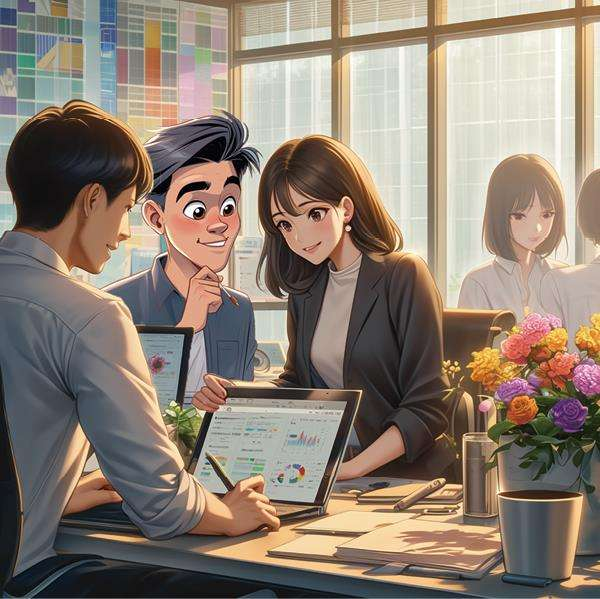

图6.1 小雪向咖哥提出了新的需求

## 6.1 复习ReAct框架

咖哥：小雪，在运营花店的过程中，我们经常遇到天气变化导致鲜花售价变化的情况。那么，每天早上你会如何为当日的鲜花定价呢？

小雪：我首先看看这个事该怎么办（ 思考 ），其次通过搜索引擎查阅网络上今天鲜花的成本价（ 行动 ），据此我可预估鲜花的进货价格，然后根据这个价格的高低（ 观察 ）来确定要加价多少（ 思考 ），最后得出售价（ 行动 ）。

小雪（人类）为鲜花定价的过程如图6.2所示。

[figure not shown]

图6.2 小雪（人类）为鲜花定价的过程

这就是我们人类在接到一个新任务时做出决策并完成下一步行动的过程。在这个简单的例子中，首先思考或者观察后再思考，然后采取行动。这里的观察和思考被统称为“推理”（Reasoning）过程，而“推理”指导人们的“行动”（Acting）。

ReAct框架的灵感来自“推理”和“行动”之间的协同作用。这种协同作用使得我们能够学习新任务并做出决策。而在大模型应用中，尤其是与Agent相关的应用开发中，我们通过提示工程向大模型植入这个思维框架，明确地告诉它们，要循序渐进地、交错地 生成推理轨迹和采取行动 ，将推理和行动融入解决问题的过程中。

ReAct框架出现之前，也有一些指导模型推理的简单框架，如强调分步思维的思维链，以及强调行动和模型与环境交互过程的SayCan <sup>[8]</sup> 和WebGPT <sup>[9]</sup> 等（见图6.3）。

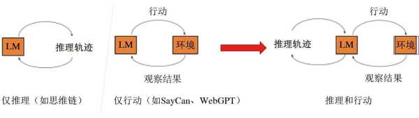

注：LM表示Language Model（语言模型），如大模型。

图6.3 从仅推理、仅执行的简单框架到ReAct框架 <sup>[3]</sup>

ReAct框架组合使用推理和行动，引导大模型生成一个任务解决轨迹：观察环境－进行思考－采取行动，也就是观察－思考－行动。

其中，推理包括对当前环境和状态的观察，并生成推理轨迹。这使得大模型能够诱导、跟踪和更新操作计划，甚至处理异常情况。行动在于指导大模型采取下一步的行动，例如与外部资源（如知识库或环境）进行交互并且收集信息，或者给出最终答案。这个过程中的信息检索有助于克服链式思考推理中常见的幻觉和错误传播问题，为任务带来更具解释性和事实性的轨迹。

与大模型仅推理，但没有采取任何行动来改变环境的状态，或者仅和环境不断交互，但不基于环境的改变来重新确定思路相比，这种模式要有效得多。

论文“ReAct: Synergizing Reasoning and Acting in Language Models” <sup>[4]</sup> 给出了一个通过不同框架解决具体问题的示例（见图6.4）。

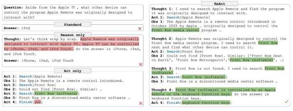

图6.4 通过不同框架解决具体问题

在图6.4中，问题是“Aside from the Apple TV, what other device can control the program Apple Remote was originally designed to interact with?”（除了苹果电视外，苹果遥控器最初被设计用来控制哪种设备？）。针对这个问题，不同框架驱动大模型解决问题的结果对比如表6.1所示。

表6.1 不同框架驱动大模型解决问题的结果对比

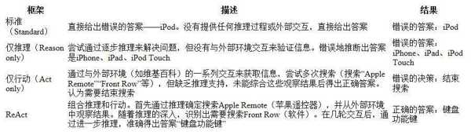

在这个示例中，ReAct框架展示了如何将推理和行动的步骤交织在一起，以支持和验证每一步的推理，最终获得一个准确且可解释的结果。在推理和行动过程中，ReAct框架提供了一个明确的、可跟踪的、类似人类思考的思维路径。由于需要与外部环境交互，因此ReAct框架解决问题时更少受到模型内部知识限制的影响。

## 6.2 LangChain中ReAct Agent 的实现

在LangChain中使用Agent时，我们只需要理解下面4个元素。

■ 大模型：提供逻辑的引擎，负责生成预测和处理输入。

■ 提示（prompt）：负责指导模型，形成推理框架。

■ 外部工具（external tools）：包括数据清洗工具、搜索引擎、应用程序等。

■ Agent执行器（Agent executor）：负责调用合适的外部工具，并管理整个流程。

根据用户的输入（接收任务），Agent会首先决定调用哪些工具，然后通过相应的工具给出答案。Agent不仅可以同时使用多种工具，而且可以将一个工具的输出数据作为另一个工具的输入数据。

上面的思路看似简单，其实值得我们仔细琢磨的地方有很多。

在整个流程中，大模型经常需要自主判断下一步的行动。如果不施加额外的引导，大模型则可能无法自主判断下一步的行动。

例如，任务是查询库存，如果库存不足，就搜索合适的商家并进货。完成这个任务需要考虑一系列的操作。

■ 什么时候开始在本地数据库中进行检索？（这是第一步，相对比较简单。）

■ 如何确定检索本地数据库的步骤已经完成，可以开始进行下一步？

■ 调用哪个外部搜索工具（例如Google）？

■ 外部搜索工具是否返回想要的内容？

■ 如何确定外部信息的真实性并执行下一步？

针对复杂、多步骤的任务，LangChain中的Agent是如何自主计划、自行判断并执行的呢？

小雪插嘴：当然是使用ReAct框架啦！

咖哥：对了。LangChain包含各种类型的Agent实现，如Self-ask with Search（自问自答结合搜索）、Structured Chat（结构化聊天）和ReAct框架等。其中最典型的是ReAct框架。

通过对ReAct框架进行完美封装和实现，LangChain可以赋予大模型极大的自主性。应用ReAct框架后，你的大模型将从一个仅仅可以借助自己内部知识进行对话聊天的机器人飞升为一个能使用工具的智能Agent。

## 6.3 LangChain中的工具和工具包

ReAct框架会提示大模型为任务生成推理轨迹和行动，这使得Agent能系统地执行动态推理以创建、维护和调整操作计划，同时还支持与外部环境（例如Google搜索、维基百科）进行交互，以将额外信息合并到推理中。这个和外部环境交互的过程其实就是我们见过多次的调用并执行工具的行动过程。上面所说的本地知识库或搜索引擎都不是封装在大模型内部的知识，我们把它们称为“外部工具”（见图6.5）。

[figure not shown]

图6.5 大模型可以通过外部工具获取额外信息

LangChain包含工具和工具包两种组件。

工具（Tools）是Agent调用的函数。这里有两个重要的考虑因素：一是让Agent能调用正确的工具；二是以最有用的方式描述这些工具。如果没有为Agent提供正确的工具，那么它将无法完成任务。如果没有正确地描述工具，那么Agent将不知道如何使用工具。除了LangChain提供的一系列的工具以外，你还可以定义自己的工具。

目前LangChain支持的工具及其说明如表6.2所示。

表6.2 LangChain支持的工具及其说明

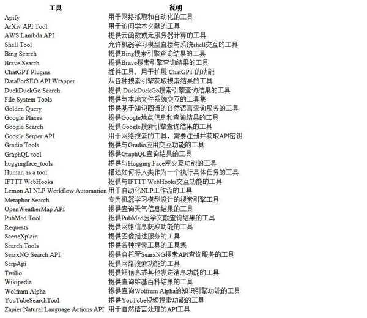

工具包（Toolkits）是一组用于完成特定目标的彼此相关的工具。每个工具包包含多个工具。例如LangChain的Office365工具包包含连接Outlook、读取邮件列表、发送邮件等一系列工具。当然LangChain中还有很多其他工具包供选择。

目前LangChain支持的工具包及其说明如表6.3所示。

表6.3 LangChain支持的工具包及其说明

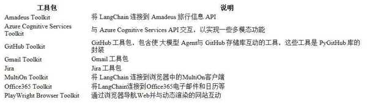

当然，表6.2和表6.3中所列的工具或工具包随着时间的推移会越来越多，这也就意味着LangChain的功能会越来越强大。

下面是一段为LangChain Agent分配工具包中工具的示例代码。

```
# 导入Gmail工具包
from langchain_community.agent_toolkits import GmailToolkit
# 初始化工具包中的所有工具
toolkit = GmailToolkit()
tools = toolkit.get_tools()
# 创建一个Agent并为Agent分配工具
from langchain.agents import create_agent
agent = create_agent(llm, tools, prompt)
```

## 6.4 通过create_react_agent创建鲜花定价Agent

在本节中，我们将利用LangChain中的create_react_agent功能来创建一个ReAct Agent。此处，我们要给Agent的任务是找出当前玫瑰花的市场价格，然后计算出加价5%后的新价格。

可以参考2.5.2节来做准备工作，如安装OpenAI、LangChain，以及在SerpApi网站注册账号，获得SERPAPI_API_KEY，并安装SerpApi的包。在本节中，我们将为大模型提供Google搜索工具。

此外，还需要安装numexpr数学工具包。这个工具包是LangChain中的llm-math工具所需要的。

```
pip install numexpr
```

设置OpenAI网站和SerpApi网站提供的API密钥。

```
# 设置OpenAI网站和SerpApi网站提供的API密钥
import os
os.environ["OpenAI_API_KEY"] = '你的OpenAI API 密钥'
os.environ["SERPAPI_API_KEY"] = '你的 SerpAPI API 密钥'
```

然后加载将用于控制Agent的大模型。

```
# 初始化大模型
from langchain_OpenAI import OpenAI
llm = OpenAI(temperature=0)
```

接下来，加载一些要使用的工具。这里，我们为大模型配备两个工具——SerpApi（这是调用Google搜索引擎的工具，用于找出当前玫瑰花的市场价格）和llm-math（这是通过大模型进行数学计算的工具，用于计算售价）。

```
# 设置工具
from langchain.agents import load_tools
tools = load_tools(["serpapi", "llm-math"], llm=llm)
```

接下来，通过设计提示模板来实现ReAct认知框架。

```
# 设计提示模板
from langchain.prompts import PromptTemplate
template = (
    '尽你所能回答以下问题。如果能力不够，你可以使用以下工具:\n\n'
    '{tools}\n\n
    Use the following format:\n\n'
    'Question: the input question you must answer\n'
    'Thought: you should always think about what to do\n'
    'Action: the action to take, should be one of [{tool_names}]\n'
    'Action Input: the input to the action\n'
    'Observation: the result of the action\n'
    '... (this Thought/Action/Action Input/Observation can repeat N times)\n'
    'Thought: I now know the final answer\n'
    'Final Answer: the final answer to the original input question\n\n'
    'Begin!\n\n'
    'Question: {input}\n'
    'Thought:{agent_scratchpad}'
)
prompt = PromptTemplate.from_template(template)
```

咖哥：这个提示模板眼熟吧？

小雪：对，我们曾使用过LangChain的Hub中用户hwchase17提供的ReAct提示模板，和这个模板非常像。

咖哥：是的。这次我们自己制作的ReAct提示还基于相同的认知框架，但是我们可以加入自己需要的内容，例如你可以要求Agent用中文回答问题、指定最终答案的格式或指明答案长度需要在100字以内等。

ReAct提示模板包含的部分及其说明如表6.4所示。

表6.4 ReAct提示模板包含的部分及其说明

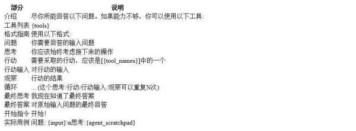

接下来使用create_react_agent函数来创建ReAct Agent，并在初始化的过程中指定大模型、工具和提示词。

```
# 初始化Agent
from langchain.agents create_react_agent
agent = create_react_agent(llm, tools, prompt)
```

下一步是创建一个AgentExecutor（Agent执行器）。

```
# 用Agent和Tools初始化一个AgentExecutor
from langchain.agents import AgentExecutor
agent_executor = AgentExecutor(agent=agent, tools=tools, verbose=True)
```

好了，现在让Agent回答我刚才提出的问题“目前市场上玫瑰花的一般进货价格是多少？如果我在此基础上加价5%，应该如何定价？”。

```
# 通过AgentExecutor执行任务
agent_executor.invoke({"input":
                       """目前市场上玫瑰花的一般进货价格是多少？\n
                       如果我在此基础上加价5%，应该如何定价？"""})
```

Agent成功遵循了ReAct框架，它输出的思考与行动轨迹如图6.6所示。

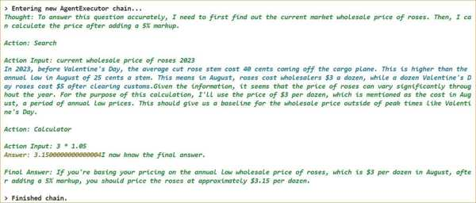

图6.6 Agent输出的思考与行动轨迹

小雪：很不错。不过，有一点不完美，这次运行中Agent给出的内容都是英文的，我有些不大适应。

咖哥：那你想想应该怎么办呢？

小雪：咖哥，只要修改一下Prompt就可以啦。

```
# 调整一下提示词
template = (
    '尽你所能用中文回答以下问题。如果能力不够，你可以使用以下工具:\n\n'
    '{tools}\n\n
     Use the following format:\n\n'
    'Question: the input question you must answer\n'
    'Thought: you should always think about what to do\n'
    'Action: the action to take, should be one of [{tool_names}]\n'
    'Action Input: the input to the action\n'
    'Observation: the result of the action\n'
    '... (this Thought/Action/Action Input/Observation can repeat N times)\n'
    'Thought: I now know the final answer\n'
    'Final Answer: the final answer to the original input question\n\n'
    'Begin!\n\n'
    'Question: {input}\n'
    'Thought:{agent_scratchpad}'
)
```

这里我们对ReAct模板做了微调，从而见识了GPT模型中英文的双语理解能力，并确保它回答问题时使用中文。否则，即使问它中文，它有时也会坚持给你“秀”英文。

再次运行程序，输出结果如图6.7所示。

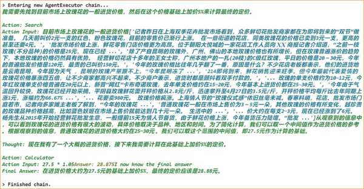

图6.7 调整Prompt之后的输出结果

可以看到， Agent在LangChain中不仅自动形成一个完善的思考与行动链条，而且给出了正确的答案。

表6.5 Agent的思考与行动链条

[figure not shown]